Pillamos los datos

```r
library(doParallel)
library(DataExplorer)
library(dplyr)
library(pROC)
library(caret)
datos <- read.csv("../data_tfg.csv")
#datos <- datos %>% select(-c(education))
#train.set <- read.csv("~/Alejandro/train_Alejandro.csv")
#test.set <- read.csv("~/Alejandro/test_Alejandro.csv")
#str(train.set)

str(datos)
```

```
## 'data.frame':    26060 obs. of  20 variables:
##  $ SITUACION: chr  "FALLECIDO" "FALLECIDO" "FALLECIDO" "FALLECIDO" ...
##  $ EDAD     : int  90 95 62 85 72 59 87 92 80 87 ...
##  $ SEXO     : chr  "MUJER" "MUJER" "HOMBRE" "HOMBRE" ...
##  $ NPC      : int  16 7 4 9 12 7 3 8 14 9 ...
##  $ NSIST    : int  10 6 2 6 6 4 3 4 7 5 ...
##  $ DM       : chr  "SI" "SI" "NO" "SI" ...
##  $ IC       : chr  "NO" "NO" "NO" "NO" ...
##  $ EPOC     : chr  "NO" "NO" "NO" "NO" ...
##  $ HTA      : chr  "SI" "NO" "NO" "NO" ...
##  $ DEP      : chr  "SI" "NO" "NO" "SI" ...
##  $ VIH      : chr  "NO" "NO" "NO" "NO" ...
##  $ CI       : chr  "NO" "SI" "NO" "SI" ...
##  $ ACV      : chr  "SI" "SI" "NO" "NO" ...
##  $ IRC      : chr  "NO" "NO" "NO" "NO" ...
##  $ CIR      : chr  "NO" "NO" "NO" "NO" ...
##  $ OST      : chr  "NO" "NO" "NO" "NO" ...
##  $ ARTROSIS : chr  "SI" "SI" "SI" "NO" ...
##  $ ARTRITIS : chr  "NO" "NO" "NO" "NO" ...
##  $ DEM      : chr  "SI" "NO" "NO" "NO" ...
##  $ DC       : chr  "NO" "NO" "NO" "NO" ...
```

Vemos como estan los datos MUY desbalanceados

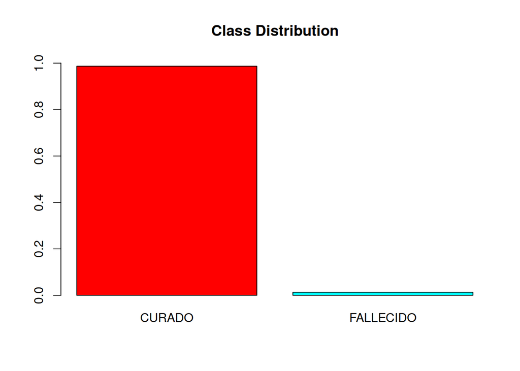

```r
barplot(prop.table(table(datos$SITUACION)),
        col = rainbow(2),
        ylim = c(0, 1.01),
        main = "Class Distribution")
```

Vemos cuanto hay de cada tipo

```r
nrow(datos[datos$SITUACION == 'CURADO',])
```

```
## [1] 25718
```

```r
nrow(datos[datos$SITUACION == 'FALLECIDO',])
```

```
## [1] 342
```

Hacemos un split de entrenamiento y test. ¿Como hago split, así normal?

```r
sample <- sample(c(TRUE, FALSE), nrow(datos), replace=TRUE, prob=c(0.7,0.3))
datos.train  <- datos[sample, ]
datos.test   <- datos[!sample, ]

nrow(datos.train)
```

```
## [1] 18269
```

```r
nrow(datos.test)
```

```
## [1] 7791
```

Vemos cuanto hay de cada tipo en train

```r
nrow(datos.train[datos.train$SITUACION == 'CURADO',])
```

```
## [1] 18012
```

```r
nrow(datos.train[datos.train$SITUACION == 'FALLECIDO',])
```

```
## [1] 257
```

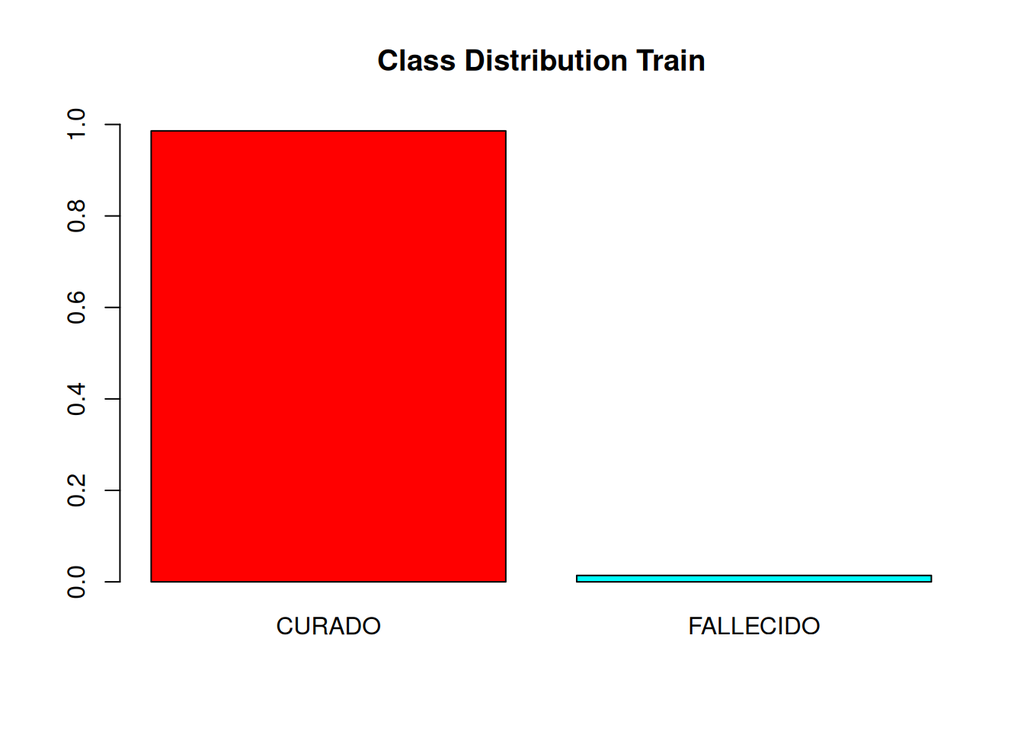

```r
barplot(prop.table(table(datos.train$SITUACION)),
        col = rainbow(2),
        ylim = c(0, 1.01),
        main = "Class Distribution Train")
```

Vemos cuanto hay de cada tipo en test

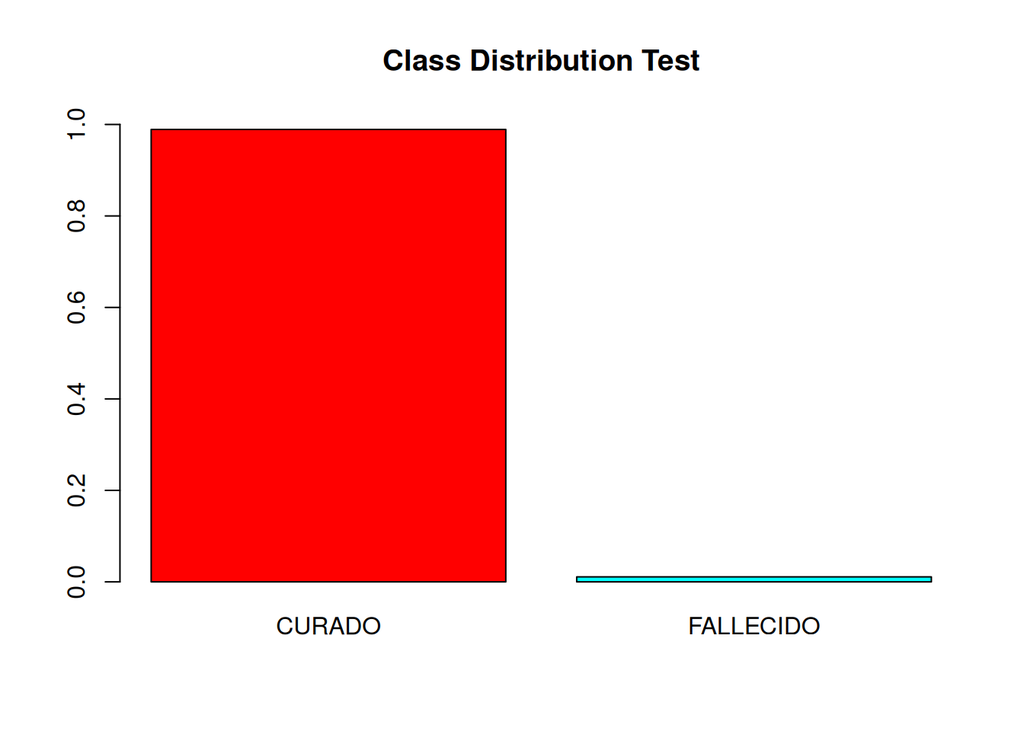

```r
barplot(prop.table(table(datos.test$SITUACION)),
        col = rainbow(2),
        ylim = c(0, 1.01),
        main = "Class Distribution Test")
```

```r
nrow(datos.test[datos.test$SITUACION == 'CURADO',])
```

```
## [1] 7706
```

```r
nrow(datos.test[datos.test$SITUACION == 'FALLECIDO',])
```

```
## [1] 85
```

Cambiamos a factores los necesarios

```r
# Deberíamos también tratar

ind.cualit <- c(which(names(datos.train) == "SITUACION"),which(names(datos.train)=="SEXO"), which(names(datos.train)=="DM"):which(names(datos.train)=="DC"))



for(i in ind.cualit){

  datos.train[,i] <- as.factor(datos.train[, i])
  datos.test[,i] <- as.factor(datos.test[, i])

}

str(datos.train)
```

```
## 'data.frame':    18269 obs. of  20 variables:
##  $ SITUACION: Factor w/ 2 levels "CURADO","FALLECIDO": 2 2 2 2 2 2 2 2 2 2 ...
##  $ EDAD     : int  95 85 72 59 87 92 87 80 91 86 ...
##  $ SEXO     : Factor w/ 2 levels "HOMBRE","MUJER": 2 1 1 1 2 1 2 1 2 2 ...
##  $ NPC      : int  7 9 12 7 3 8 9 3 7 15 ...
##  $ NSIST    : int  6 6 6 4 3 4 5 2 3 9 ...
##  $ DM       : Factor w/ 2 levels "NO","SI": 2 2 2 2 2 2 2 1 2 2 ...
##  $ IC       : Factor w/ 2 levels "NO","SI": 1 1 1 1 1 1 1 1 1 1 ...
##  $ EPOC     : Factor w/ 2 levels "NO","SI": 1 1 1 1 1 1 1 1 1 1 ...
##  $ HTA      : Factor w/ 2 levels "NO","SI": 1 1 2 2 1 2 1 1 2 2 ...
##  $ DEP      : Factor w/ 2 levels "NO","SI": 1 2 1 1 1 1 1 1 1 2 ...
##  $ VIH      : Factor w/ 2 levels "NO","SI": 1 1 1 1 1 1 1 1 1 1 ...
##  $ CI       : Factor w/ 2 levels "NO","SI": 2 2 2 1 1 1 1 1 2 1 ...
##  $ ACV      : Factor w/ 2 levels "NO","SI": 2 1 2 1 1 1 2 1 1 2 ...
##  $ IRC      : Factor w/ 2 levels "NO","SI": 1 1 1 2 1 1 1 1 1 1 ...
##  $ CIR      : Factor w/ 2 levels "NO","SI": 1 1 1 1 1 1 1 1 1 2 ...
##  $ OST      : Factor w/ 2 levels "NO","SI": 1 1 1 1 1 1 1 1 1 1 ...
##  $ ARTROSIS : Factor w/ 2 levels "NO","SI": 2 1 1 1 1 1 1 1 1 2 ...
##  $ ARTRITIS : Factor w/ 2 levels "NO","SI": 1 1 1 1 1 1 1 1 1 1 ...
##  $ DEM      : Factor w/ 2 levels "NO","SI": 1 1 2 1 1 2 2 1 1 1 ...
##  $ DC       : Factor w/ 2 levels "NO","SI": 1 1 1 1 1 1 1 1 1 1 ...
```

Aplicamos p-subsets

```r
muertos <- datos.train %>% dplyr::filter(SITUACION == "FALLECIDO")
nrow(muertos)
```

```
## [1] 257
```

```r
sanos <- datos.train %>% filter(SITUACION == "CURADO")
nmin <- nrow(muertos)
alpha <- .01
```

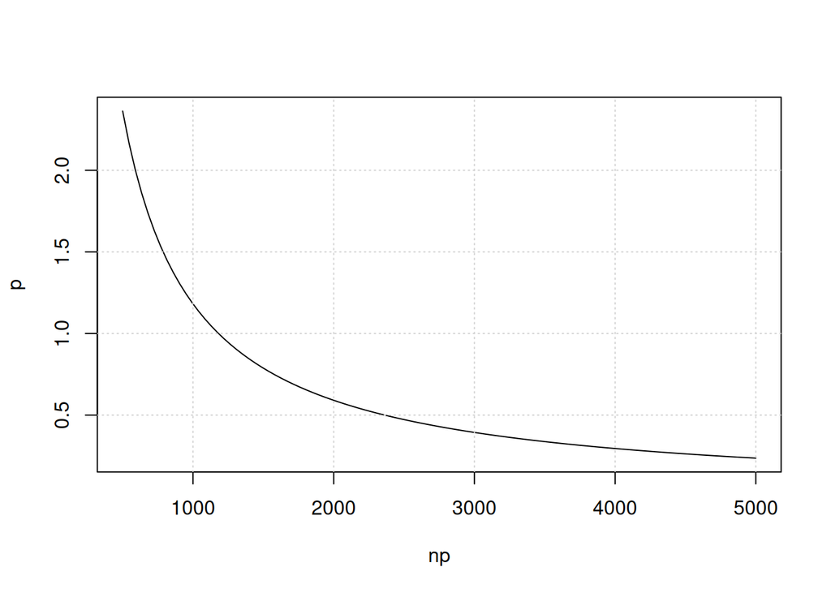

```r
curve(log(alpha)/(log(1-1/nmin)*np), from = 500, to = 5000, xname = "np", ylab = "p")
grid()
```

```r
np <- ceiling(nmin*0.75)
np
```

```
## [1] 193
```

Queremos el 75%

```r
p <- log(alpha)/(log(1-1/nmin)*np)
p
```

```
## [1] 6.120335
```

Tendremos que coger 7 modelos.

```r
prop.mayoritaria<-0.55
set.seed(42)
p <- ceiling(p)
dfs <- list()
# Seleccionamos todos los  sanos que usaremos, y los reordenamos

for(k in 1:p){
  id.muertos <- sample(x = 1:nrow(muertos), size = np) #Índices de clase minoritaria para cada subconjunto
  id.sanos <- sample(x= 1:nrow(sanos), size = round(np*prop.mayoritaria/(1-prop.mayoritaria))) #Índices de la clase mayoritaria para cada subconjunto

  dfs[[k]] <- rbind(muertos[id.muertos,],sanos[id.sanos,])
}
```

Ver cuantos vectores distintos hay y su dimensión (número de features)

```r
unique(unlist(lapply(dfs,dim)))
```

```
## [1] 429  20
```

```r
unique(lapply(dfs,function(x) prop.table(table(x$SITUACION))))
```

```
## [[1]]
##
##    CURADO FALLECIDO
## 0.5501166 0.4498834
```

Ahora tomamos los hiperparámetros y hacemos el entrenamiento en random forest:

```r
hiperparametros <- expand.grid(
  mtry = 0:6*3+1,
  min.node.size = 1:3*10-9,
  splitrule = "gini"
)
hiperparametros
```

```
##    mtry min.node.size splitrule
## 1     1             1      gini
## 2     4             1      gini
## 3     7             1      gini
## 4    10             1      gini
## 5    13             1      gini
## 6    16             1      gini
## 7    19             1      gini
## 8     1            11      gini
## 9     4            11      gini
## 10    7            11      gini
## 11   10            11      gini
## 12   13            11      gini
## 13   16            11      gini
## 14   19            11      gini
## 15    1            21      gini
## 16    4            21      gini
## 17    7            21      gini
## 18   10            21      gini
## 19   13            21      gini
## 20   16            21      gini
## 21   19            21      gini
```

Siendo la función de predicción del modelo para cada modelo de cada subproblema

```r
prediccion <- function(conj.model, x, q = 0.75){ #q=0.75, pero se deberían probar valores como 0.5, 0.25, 0.75...
  pred <- data.frame(matrix(nrow=nrow(x),ncol=0))
  for(modelo in conj.model) pred <- cbind(pred, predict(modelo,x))
  pred <- apply(pred, 1, function(x) prop.table(table(x))["CURADO"])
  ifelse(is.na(pred) | pred<q, "FALLECIDO", "CURADO")
}
```

Nos falta el valor de b que es el número de modelos que habrá en cada conjunto. Para eso usamos formula similar a la superior:

```r
alpha_b <- 0.01
b <- ceiling(log(alpha_b)/(log(1-1/np)*np))
b
```

```
## [1] 5
```

Las métricas, especialmente KAPPA (igual ROC después)

```r
metricas <- function(data, lev = levels(as.factor(data$obs)), model = NULL){
  c(
    ACCURACY = MLmetrics::Accuracy(data[, "pred"], data[, "obs"]),
    SENS = sensitivity(data[, "pred"],data[, "obs"],positive="FALLECIDO",negative="CURADO"),
    SPEC = specificity(data[, "pred"], data[, "obs"],positive="FALLECIDO",negative="CURADO"),
    PPV = posPredValue(data[, "pred"], data[, "obs"],positive="FALLECIDO",negative="CURADO"),
    NPV = negPredValue(data[, "pred"], data[, "obs"],positive="FALLECIDO",negative="CURADO"),
    KAPPA = psych::cohen.kappa(cbind(data[, "obs"],data[, "pred"]))$kappa,
    BAL_ACC = (sensitivity(data[, "pred"],data[, "obs"],positive="FALLECIDO",negative="CURADO") + specificity(data[, "pred"], data[, "obs"],positive="FALLECIDO",negative="CURADO"))/2
  )
}

tC <- trainControl(
  summaryFunction = metricas,
  method = "cv",
  number = 5,
  allowParallel = TRUE,
  classProbs = TRUE
)
```

Ahora calculamos una manera de ver ‘mt’, que es las veces que el algoritmo se puede equivocar o no aportar suficiente en un problema dado. Como conforme el cardinal de E sea mayor, menos probable es que el modelo aporte, así que vamos a hacerlo inversamente proporcional al mismo. (b siempre es mayor que n)

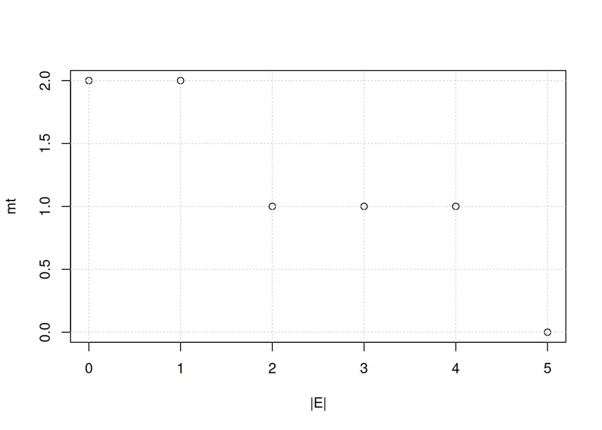

```r
mt <- function(n) { ceiling((b-n) / 3) }
plot(0:b, mt(0:b), xlab = "|E|", ylab = "mt")
grid()
```

Procedemos directamente a entrenar cada subproblema con sus modelos:

```r
E <- list() # Modelo final (ensemble de ensembles)
set.seed(12)

for(k in 1:p){
  Ek <- list() # Ensemble de modelos k-ésimo
  i <- 0 # Contador para el número de intentos de ampliar el ensemble
  # Conjunto de datos balanceado:
  df <- dfs[[k]]

  while(length(Ek)<=b && i<mt(length(Ek))){
    # Seleccionamos muestras para entrenar el modelo de random forest (modelo a elegir realmente)
    mayoritaria <- which(df$SITUACION == "CURADO")
    minoritaria <- which(df$SITUACION == "FALLECIDO")
    ind.train <- c(
      sample(mayoritaria, size = round(np*prop.mayoritaria/(1-prop.mayoritaria)), replace = TRUE),
      sample(minoritaria, size = np, replace = TRUE) #Se puede probar sin reemplazamiento en ambos samples
    )

       cl <- makeCluster(detectCores()-2)
      registerDoParallel(cl)

    rf <- train(
      x = df[ind.train,-1],
      num.trees = 200,
      importance = "impurity",
      y = df$SITUACION[ind.train],
      method = "ranger",
      metric = "KAPPA", #Buscamos maximizar el kappa
      maximize = T,
      trControl = tC,
      tuneGrid = hiperparametros
    )

    stopCluster(cl)

    # Evaluamos el ensemble actual (sin el nuevo modelo)
    metricas.ensemble <-
      if (length(Ek)==0){
        u <- -Inf;
        names(u) <- "KAPPA";
        u;
      } else metricas(data.frame(
              obs = datos.test$SITUACION,
              pred= as.factor(prediccion(Ek, datos.test[-1]))
           ))
    Ek[[length(Ek)+1]] <- rf
    # Evaluamos el ensemble formado al añadir el nuevo modelo
    metricas.ensemble.2 <- metricas(data.frame(
      obs = datos.test$SITUACION,
      pred= as.factor(prediccion(Ek, datos.test[-1]))
    ))
    # Comparamos las metricas
    if(metricas.ensemble.2["KAPPA"] <= metricas.ensemble["KAPPA"]){ # Si el ensemble no mejora con el nuevo modelo...
      i <- i+1
      Ek[[length(Ek)]] <- NULL
    } else{ # En caso de ampliar el ensemble, reseteamos las oportunidades de cara a una nueva ampliación
      i <- 0
    }

  } # Fin del WHILE (hemos terminado de construir el ensemble k-ésimo)

  # Guardamos la información del ensemble k-ésimo
  E[[length(E)+1]] <- Ek

} # FIN. Hemos terminado de contruir el ensemble final
saveRDS(E,"./TrainCompleto.rds")
```

```r
ensemble <- readRDS("TrainCompleto.rds")
```

Veamos los modelos que son

```r
unlist(lapply(ensemble,length))
```

```
## [1] 1 1 1 1 1 1 1
```

Ahora hacemos el ensemble y predecimos:

```r
prediccion.final <- function(ensemble, x, q = 0.5){
  # Colocamos en cada fila de un conjunto de datos todas las predicciones para una muestra
    pred <- as.data.frame(lapply(ensemble, function(e) prediccion(e,x)))
  pred <- apply(pred, 1, function(x) prop.table(table(x))["CURADO"])
  ifelse(is.na(pred) | pred<q, "FALLECIDO", "CURADO")
}
```

```r
metricas.final.rf<- metricas(data.frame(
    obs = datos.test$SITUACION,
    pred= as.factor(prediccion.final(ensemble, datos.test[-1]))
))
```

Vemos el resultado

```r
metricas.final.rf
```

```
##  ACCURACY      SENS      SPEC       PPV       NPV     KAPPA   BAL_ACC
## 0.8799897 0.8941176 0.8798339 0.0758483 0.9986743 0.1221781 0.8869758
```